# Clinical Trial Statistics for Clinical Investigators

Phil Boonstra, PhD

2025-07-21

## Overview of phases of clinical research

Phase I: Identify maximum tolerated dose (MTD) of the treatment

Phase II: Determine if treatment is unlikely to be effective

Phase III: Compare efficacy of study drug(s) to standard of care

## Phase I: Identify the Maximum Tolerated Dose (MTD)

Conventional assumption in oncology: potential for harm to patient and harm to cancer both increase with dose

This assumption has driven phase I clinical trial design for decades:

1. Identify toxicity outcomes of concern (usually short-term)
2. Name your trial’s “red line”, e.g. no dose that induces toxicity in more than 1/3 of patients is acceptable
3. First patient starts on known, safe dose. Subsequent patients are assigned to higher doses as appropriate

The MTD is the largest dose that does not exceed your red line

## Examples

3+3 design: enroll patients in groups of 3 (and possibly 3 more) at each dose level. MTD is largest dose at which no more than 1/3 of patients experience toxicity

More sophisticated conventional designs use a statistical model to estimate the MTD, e.g. the Continual Reassessment Method (CRM) (Goodman, Zahurak and Piantadosi, 1995), modified toxicity probability interval (MTPI) (Ji and Wang, 2013), or Bayesian optimal interval design (BOIN) (Yuan et al., 2016)

https://www.trialdesign.org/

## Challenges to conventional phase I designs

Chasing after short-term toxicity can lead you astray:

1. The design is built to succeed: you’ll nearly always be able to estimate an MTD (but it may turn out to be inefficacious) (Thall et al., 2024)
2. Focusing on short-term toxicity may be: patients for whom the drug is intended are living longer and on treatment for longer, e.g. “People can’t live with grade two diarrhea for a year” (Cheung and Garrett-Mayer, 2025)
3. Conventional assumption about toxicity-efficacy relationship may not hold for many agents (Shah et al., 2021)

57.6% of oncology phase I trials make it phase II, but just 6.7% of phase II trials lead to eventual approval (Wong, Siah and Lo, 2019)

## Phase II: Determine if treatment is unlikely to be effective

- Looking for evidence of activity, with respect to what is already available to patients
  - Typically 50-100 patients
  - Efficacy endpoint that can be observed quickly
  - May be randomized but not necessarily
- “Phase II” is convenient word but loosely defined
- Piantadosi (2005) uses term *middle development*

## Why is Phase II needed?

Taken from Piantadosi (2005), p373

- First evidence of activity using meaningful clinical outcome
- Longer-term evaluation of safety
- Feasibility of administering new treatment
- Fine-tune dose, schedule
- Practice for definitive study
- Determine whether definitive study is warranted
- “Depressure pipeline”

## Drug Development Pipeline

- Let $W$ denote drugs that are worthwhile, $W^C$ denote drugs that are not
- Illustration of phase II goal:

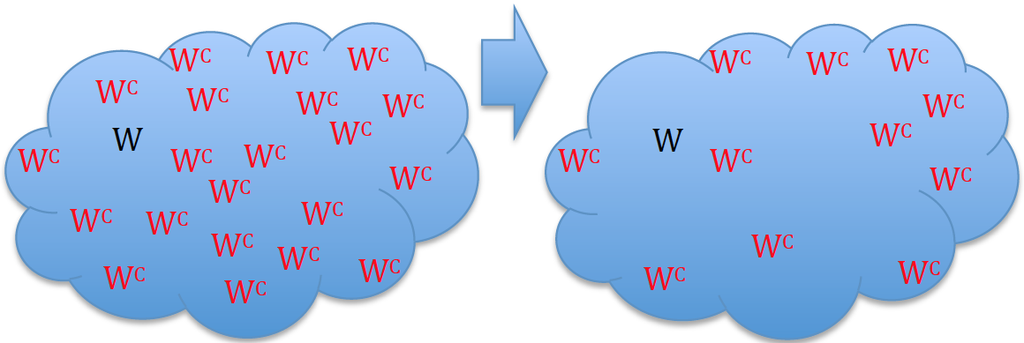

## Detour: Diagnostic testing and Bayes Theorem

If diagnostic test is positive for a disease, what is the post-test probability that the patient has the disease? Bayes Theorem gives us the answer:

$$\Pr(D+|T+) = \dfrac{\Pr(T+|D+)\Pr(D+)}{\Pr(T+|D+)\Pr(D+) + \Pr(T+|D-)\Pr(D-)}$$
$\Pr(D+|T+)=$ post-test probability that patient has disease;

$\Pr(T+|D+)=$ probability of testing positive if patient has disease (sensitivity);

$\Pr(T+|D-)=$ probability of testing positive if patient does not have disease (one minus specificity);

$\Pr(D+)=$ prevalence of disease in the population

$$\Pr(D+|T+) = \dfrac{\text{sens}*\text{prev}}{\text{sens}*\text{prev} + (1-\text{spec})*(1-\text{prev})}\\ = \dfrac{0.80*0.05}{0.80*0.05 + 0.10*0.95}\approx 30\%$$

## Drug Development Pipeline

Phase II goal is to enrich phase III population with worthwhile drugs so that positive findings in phase III are highly likely to be true positives:

- If 30% of drugs entering phase 3 study are truly worthwhile, $\alpha = 0.05$ (smaller than phase II), and $\beta = 0.10$ (smaller than phase II), then $(0.90*0.30)/(0.90*0.30 + 0.05*0.70)\approx 89\%$ of drugs leaving phase 3 study, i.e. submitted for regulatory approval, are truly worthwhile

## Most common Phase II design

Simon’s two-stage design (Simon, 1989) by far most common design in phase II trials. More than 4000 citations as of July 2025.

1. Identify efficacy outcomes of interest, typically efficacy outcome that does not take too long to observe, and identify “uninteresting” and “interesting” thresholds
2. Enroll cohort of $n_1$ patients, follow for outcome. Decide if worthwhile to continue.
3. Enroll cohort of $n_2$ more patients, declare success or failure.

## Project Optimus

*Reforming the dose optimization and dose selection paradigm in oncology*

US FDA’s push to incorporate optimization strategies into designs: randomization across dose levels, PK/PD, efficacy and QOL outcomes.

https://www.fda.gov/about-fda/oncology-center-excellence/project-optimus

*Clinical Trials* special issue on dose optimization

https://journals.sagepub.com/toc/ctja/21/3

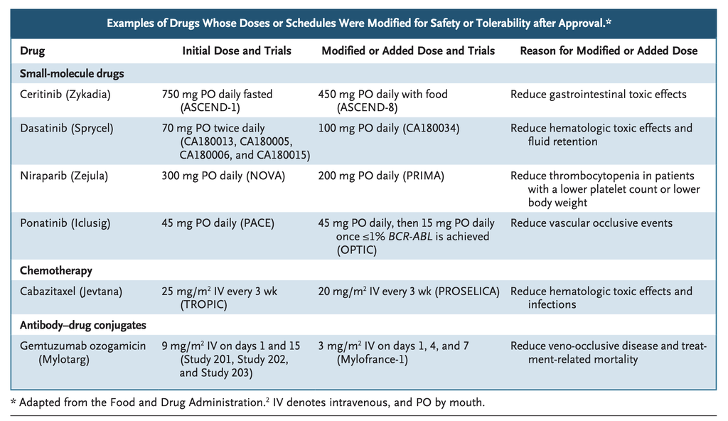

Figure 1, Shah et al. (2021)

## Seamless Phase I/II designs

A seamless design is one practical way to achieve some of the goals of Project Optimus.

Seamless designs combine phase I and phase II into a single trial, with the goal of identifying MTD and assessing efficacy in a single trial (Boonstra, Braun and Chase, 2021), (Boonstra et al., 2017)

Seamless designs are ideally *not* just phase I trials followed by a adhoc additional cohort of patients at the MTD (Boonstra et al., 2015)

- Sometimes just a Phase I and Phase II mashed together into one protocol, e.g. 3+3 design followed by Simon’s two-stage design (Jaki et al., 2023)
- Better to incorporate both toxicity and efficacy for making dosing decisions throughout the trial e.g. the EffTox design (Thall and Cook, 2004)
- Generally require more statistical support and clinician input

## Phase III

Typical hallmarks of Phase III trials:

1. Large (hundreds or thousands of patients)
2. Randomized, including standard of care
3. Clinically relevant endpoints (overall survival instead of response)
4. Support regulatory approval for labels.
5. Often designed and written by study sponsor

## Other thoughts / Phil’s rants

Rogel’s Cancer Data Science (CDS) shared resource provides biostatistical support for the development of investigator-initiated trials (IITs).

https://www.rogelcancercenter.org/research/shared-resources-and-cores/cancer-data-science

These are usually Phase I/II trials.

CDS doesn’t support using the 3+3 design in Phase I trials, and the Protocol Review Committee (PRC) doesn’t approve IIT protocols that use it.

## Endpoints vs parameters vs objectives

- Endpoints are the data you are measuring for each patient, e.g. grade >=3 hematologic toxicity, best overall response
- Parameters are unknown population level summaries to be estimated, e.g. maximum tolerated dose, grade >=3 hematologic toxicity rate, best overall response rate
- Objectives are the goals of the study, usually accompanied by a specific hypothesis, e.g. to demonstrate that the complete response rate is 30% or higher

When a paper states “The trial met its primary endpoint” it usually means “The trial achieved its primary objective”

## Phase I checklist of questions from your statistician

- Number of agents with varying doses?
- How many doses of each agent?
- What toxicities will be considered DLTs?
- What is an acceptable maximum DLT rate?
- How many patients can you afford (in time and dollars)?
- Toxicity (MTD/MTC) or Toxicity & Efficacy (BOD/BOC)?
  - What is a response (tumor size or biologic target, i.e. PK/PD)?
  - What is minimum acceptable response rate?

## Phase II checklist of questions from your statistician

- More than one dose level?
- What is your patient population? If the treatment is targeted, how will this impact eligibility?
- How many patients can you afford (in time and dollars)?
- How is response defined (tumor size or biologic target, i.e. PK/PD)?
- What is minimum acceptable response rate?

## References

Boonstra, P.S., Braun, T.M. and Chase, E.C. (2021) A modular framework for early-phase seamless oncology trials. *Clinical Trials*, **18**, 303–313.

Boonstra, P., Braun, T., Taylor, J., Kidwell, K., Bellile, E., Daignault, S., et al. (2017) Statistical controversies in clinical research: Building the bridge to phase II—efficacy estimation in dose-expansion cohorts. *Annals of Oncology*, **28**, 1427–1435.

Boonstra, P.S., Shen, J., Taylor, J.M., Braun, T.M., Griffith, K.A., Daignault, S., et al. (2015) A statistical evaluation of dose expansion cohorts in phase i clinical trials. *Journal of the National Cancer Institute*, **107**, dju429.

Cheung, K. and Garrett-Mayer, E. (2025) Sixteenth annual university of pennsylvania conference on statistical issues in clinical trial/optimizing dose-finding across the clinical trials spectrum (morning panel discussion). *Clinical Trials*, 17407745251351291.

Goodman, S.N., Zahurak, M.L. and Piantadosi, S. (1995) Some practical improvements in the continual reassessment method for phase i studies. *Statistics in medicine*, **14**, 1149–1161.

Jaki, T., Burdon, A., Chen, X., Mozgunov, P., Zheng, H. and Baird, R. (2023) Early phase clinical trials in oncology: Realising the potential of seamless designs. *European Journal of Cancer*, **189**, 112916.

Ji, Y. and Wang, S.-J. (2013) Modified toxicity probability interval design: A safer and more reliable method than the 3+ 3 design for practical phase i trials. *Journal of Clinical Oncology*, **31**, 1785–1791.

Piantadosi, S. (2005) *Clinical Trials: A Methodologic Perspective*. John Wiley & Sons.

Shah, M., Rahman, A., Theoret, M.R. and Pazdur, R. (2021) The drug-dosing conundrum in oncology—when less is more. *New England Journal of Medicine*, **385**, 1445–1447.

Simon, R. (1989) Optimal two-stage designs for phase II clinical trials. *Controlled clinical trials*, **10**, 1–10.

Thall, P.F. and Cook, J.D. (2004) Dose-finding based on efficacy–toxicity trade-offs. *Biometrics*, **60**, 684–693.

Thall, P.F., Garrett-Mayer, E., Wages, N.A., Halabi, S. and Cheung, Y.K. (2024) Current issues in dose-finding designs: A response to the US food and drug adminstration’s oncology center of excellence project optimus. *Clinical Trials*, **21**, 267–272.

Wong, C.H., Siah, K.W. and Lo, A.W. (2019) Estimation of clinical trial success rates and related parameters. *Biostatistics*, **20**, 273–286.

Yuan, Y., Hess, K.R., Hilsenbeck, S.G. and Gilbert, M.R. (2016) Bayesian optimal interval design: A simple and well-performing design for phase i oncology trials. *Clinical Cancer Research*, **22**, 4291–4301.